# Hold the line please - Brisbane Telephone Exchange | State Library Of Queensland

[State Library of Queensland](https://www.slq.qld.gov.au/)

Blog

Topics

[John Oxley Library](https://www.slq.qld.gov.au/blog/john-oxley-library)

# Hold the line please - Brisbane Telephone Exchange

By Simon Miller, Library Technician, State Library of Queensland | 7 May 2013

I notice that we recently passed the 40th anniversary of the invention of the mobile phone. The telephone is now ubiquitous but you might be surprised at how quickly it arrived in Brisbane after its invention. Alexander Graham Bell demonstrated the first practical telephone in 1876 and published details in the *Scientific American* on 6 October 1877. The first experiments with telephones in Queensland were conducted at the Brisbane GPO on 26 January 1878 by W. J. Cracknell, Superintendant of Telegraphs. Cracknell was able to set up a demonstration of the telephones at the Exhibition in August of that year along with some other startling scientific exhibits as reported in the minutes of the National Association published in the [Brisbane Courier](http://nla.gov.au/nla.news-article1373334).

*That to Mr. W. J. Cracknell, Superintendent of Telegraphs, your committee are indebted for the promise of several highly interesting scientific exhibits at next month's exhibition, all of which are comparatively unknown in Queensland, viz.:*

*1. The electric light, to be displayed every evening.*

*2. Explosion of torpedoes in the creek running through Bowen Park, by means of electricity.*

*3.Telephones fitted up in the main building, and in the park, by which visitors may, at distant points from each other, converse through the medium of these wonderful instruments.*

These early telephones could only be used for communication between two fixed points but January 1878 saw the opening of the first commercial telephone exchange which allowed multiple telephone users to be connected and made the instrument truly practical. Brisbane's first telephone exchange was set up at the GPO linking several Government offices in October 1880 and by 1881 there were 36 telephones connected including several private ones. By 1883 a continuous 24 hour service was being provided and 175 telephones were connected. The first country telephone exchange in Australia was opened in Maryborough in 1882 with 32 subscribers.

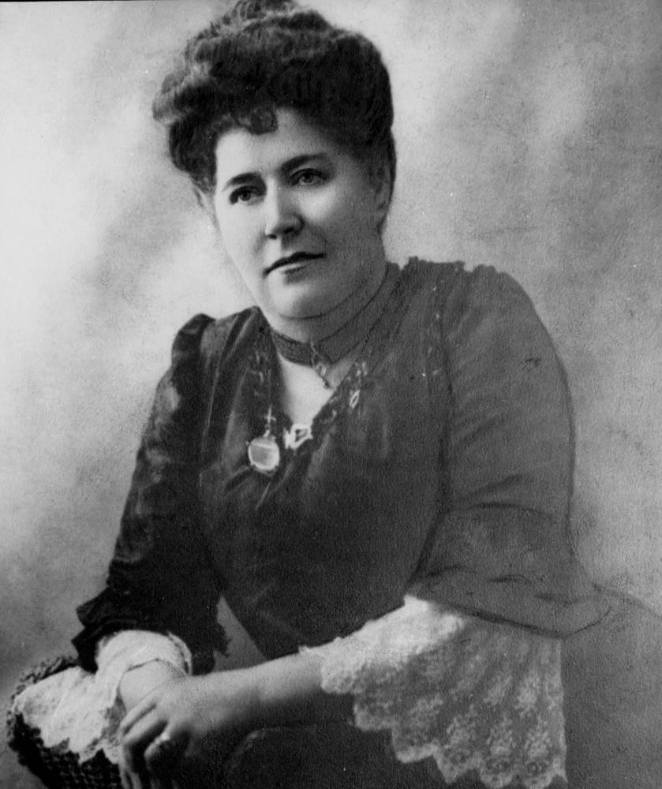

[Mrs William Heddle Dick, First Lady Superintendent of the First Telephone Exchange in the Colony of Queensland. John Oxley Library. State Library of Queensland Neg 60492](https://www.slq.qld.gov.au/media/27518)

Mrs William Heddle Dick, First Lady Superintendent of the First Telephone Exchange in the Colony of Queensland. John Oxley Library. State Library of Queensland Neg 60492

Alterations were made to the building to allow for the employment of female operators, who worked from 8 am to 6 pm, the night shift being deemed unsuitable for female employment. An article published in [The Queenslander](http://nla.gov.au/nla.news-article22558074) and attributed to 'Delphia' provides a detailed description of the working environment of these early telephonists.

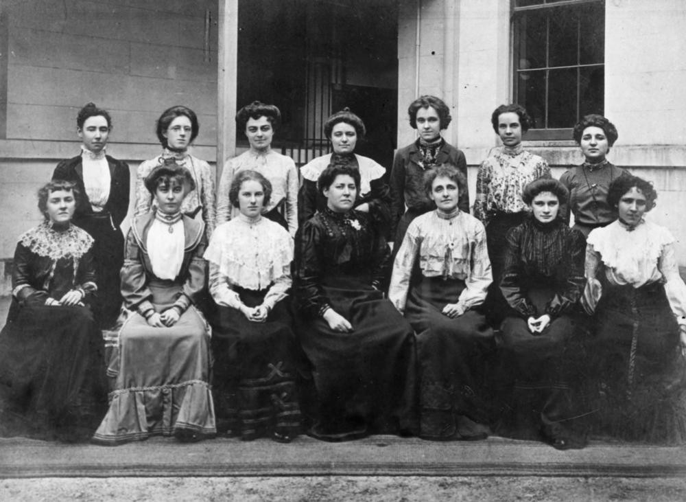

[Group of the first female telephonists in Brisbane, Queensland started in June 1899. John Oxley Library State Library of Queensland Image no. 7185-0001-0029](https://www.slq.qld.gov.au/media/27519)

Group of the first female telephonists in Brisbane, Queensland started in June 1899. John Oxley Library State Library of Queensland Image no. 7185-0001-0029

*The new switchboard on the Telephone Exchange is now in working order; and the female operators are shaping to their novel experience in a manner that augurs well for their future utility, and for the increased convenience of the public service. Mrs. Dick, the lady superintendent, assisted by a monitress, has twelve operators under her charge. Perhaps a more capable-looking assemblage of young women could hardly be found In Brisbane; had the qualification been appearance only, instead of capability, they could well have stood the test. It is somewhat surprising, considering the small amount of salary offered, that such a refined and superior class of workers should have tendered their services, especially when. It is found that some of them come from a distance, as far as Ipswich even, and have to deduct travelling expenses from their earnings. They, no doubt, look upon the appointment as a beginning of better things, and anticipate future promotions in the Government service. It must also be borne in mind that, although they, have passed the necessary education tests, they are ignorant of the telephone duties, until patiently inducted into the method, under the personal supervision of Mr. Hesketh.*

*The girls enter their offices through a private door on the right hand of the Post Office lane, near Elizabeth-street. After ascending, two flights of narrow stairs, we find the lavatories on the right hand, with necessary fittings, and a comfortable little sitting-room on the left. Around the walls, convenient lockers are fitted up, a separate one, with lock and key, for each operator ; the open doors show a good arrangement for hanging hats and cloaks, and shelves for cups, lunch, books, &c.; outside, they look like wardrobes of polished Maryborough pine. One or two cane lounges, plenty of comfort-able chairs, a large table, and writing secretaire form part of the comfortable furnishings. In one corner a small gas stove is fitted, and a large kettle supplies hot water for the acceptable cup of tea at lunch time. The pretty light tint chosen for the wall colouring gives a brightness to the room and in every way possible in so small a space has the comfort of the girls when off duty been considered. Mrs. Dick is ever on the alert to see that the girls are relieved of duty for a time, when they feel the nervous strain too much, or when the incessant vibration tells upon their endurance. That there will be cause for watchfulness and anxiety in this respect a visit to the switchboard room will show. Such a babel of confused and subdued voices, in the strident, "are you-there" tone. The operators sit in chairs constructed upon pedestals to move slightly from side to side, so as to quickly operate upon the numbers from right to left. Each operator has 100 connections under her charge. To watch the incessant manipulation of the plugs, one would imagine that every telephone-owner spent a good part of his time with a transmitter at his mouth. Ten in the morning is the busiest hour, between 12 and 2 the switching slackens, and increase afterwards up to 4 o'clock.*

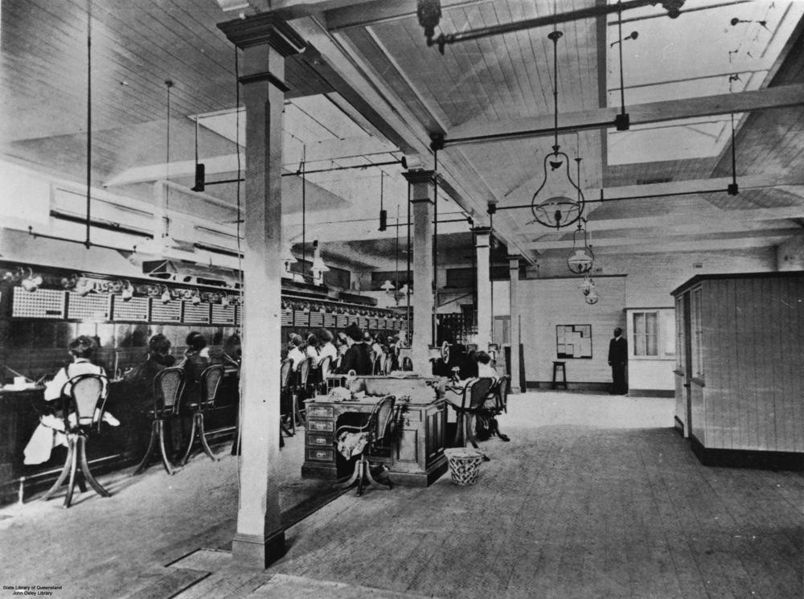